# How Fast Can You Type A Million Letters?

Prepared for FiveThirtyEight Riddler Classic April 27, 2018

### How I Solved It

I used an iterrative optimization approach to solve this problem. I found a non-linear constrained optimization library in R `library(nloptr)` that implements the NLopt library. I set up the optimizer to minimize the sum of the times spent on various methods (including the delays specified in the problem), subject to the constraint that one million i characters are typed. First I tried this without copy-paste cycles, and then progressively added additional copy-paste cycles. It took six c/p cycles until the decrease in total time leveled off. I chose the solution with five copy-paste cycles for a total time of 41 seconds. Please note that this optimizer doesn’t do integer optimization, so I hand tweaked (rounding up or down) the solutions to get whole numbers. I used the sign() function to model the fixed costs of operations such as copy/paste cycles. For optimizing I chose the COBYLA (Constrained Optimization BY Linear Approximations) algo, which allows inequality constraints without the need to specify gradients and jacobian matrices.

The video of me doing this live is here: http://vimeo.com/267043908

I managed to beat the optimizer.

# Chart of Optimizer Results

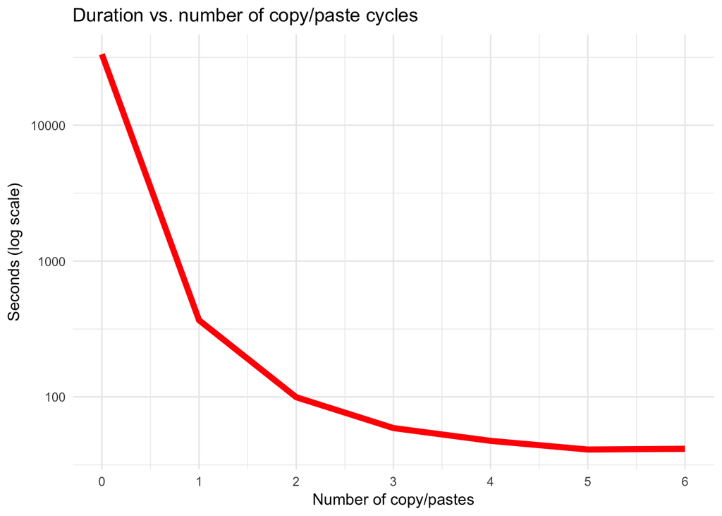

# Initial test without copy/paste: 33333.83 seconds

```r
# Set up 2-part objective function to minimize (single keystrokes and auto-repeat keys)
eval_f <- function(x) ( x[1] + x[2] +0.5*sign(x[2]) )
# Set up constraint function to 1e6 values
eval_g0 <- function(x)  return( -(5*x[1] + 30*x[2] - 1e6))
# Initial guesses
x0 <- c(100,10000)
# Algo options (constrained optimization and tolerance)
opts <- list("algorithm"="NLOPT_LN_COBYLA",   "xtol_rel"=0.01)
# Run the minimization algo
res <- nloptr( x0=x0, eval_f=eval_f,eval_g_ineq = eval_g0, opts=opts,lb=c(0,0))
print(res)
```

```
##
## Call:
##
## nloptr(x0 = x0, eval_f = eval_f, lb = c(0, 0), eval_g_ineq = eval_g0,
##     opts = opts)
##
##
## Minimization using NLopt version 2.4.2
##
## NLopt solver status: 5 ( NLOPT_MAXEVAL_REACHED: Optimization stopped
## because maxeval (above) was reached. )
##
## Number of Iterations....: 100
## Termination conditions:  xtol_rel: 0.01
## Number of inequality constraints:  1
## Number of equality constraints:    0
## Current value of objective function:  33333.8333333333
## Current value of controls: 0 33333.33
```

# Copy/paste once: about 367 seconds

```r
# Set up 3-part objective function (single keystrokes, auto-repeat keys, and 1x c/p)
eval_f <- function(x) ( x[1] + x[2]+0.5*sign(x[2]) + x[3]+1.5*sign(x[3]) )
# Set up constraint function to 1e6 values
eval_g0 <- function(x)  return( -(5*x[1] + 30*x[2] + (5*x[1] + 30*x[2])*x[3] - 1e6))
# Initial guesses
x0 <- c(100,200,200)
# run the minimization algo
res <- nloptr( x0=x0, eval_f=eval_f,eval_g_ineq = eval_g0, opts=opts,lb=c(0,0,0))
print(res)
```

```
##
## Call:
##
## nloptr(x0 = x0, eval_f = eval_f, lb = c(0, 0, 0), eval_g_ineq = eval_g0,
##     opts = opts)
##
##
## Minimization using NLopt version 2.4.2
##
## NLopt solver status: 4 ( NLOPT_XTOL_REACHED: Optimization stopped because
## xtol_rel or xtol_abs (above) was reached. )
##
## Number of Iterations....: 46
## Termination conditions:  xtol_rel: 0.01
## Number of inequality constraints:  1
## Number of equality constraints:    0
## Optimal value of objective function:  366.138703192697
## Optimal value of controls: 6.483068e-18 181.5168 182.6219
```

# Copy/paste twice: 99.5 seconds

```r
# Set up 4-part objective function (single keystrokes, auto-repeat keys, and 2x c/p)
eval_f <- function(x) ( x[1] + x[2]+0.5*sign(x[2]) + x[3]+1.5*sign(x[3]) + x[4]+1.5*sign(x[4]) )
# Set up constraint function to 1e6 values
eval_g0 <- function(x)  return( -(5*x[1] + 30*x[2] + (5*x[1] + 30*x[2])*x[3] +
                                    ((5*x[1] + 30*x[2])*x[3])*x[4] - 1e6))
# Initial guesses
x0 <- c(100,100,100,100)
# Run the minimization algo
res <- nloptr( x0=x0, eval_f=eval_f,eval_g_ineq = eval_g0, opts=opts,lb=c(0,0,0,0))
print(res)
```

```
##
## Call:
##
## nloptr(x0 = x0, eval_f = eval_f, lb = c(0, 0, 0, 0), eval_g_ineq = eval_g0,
##     opts = opts)
##
##
## Minimization using NLopt version 2.4.2
##
## NLopt solver status: 4 ( NLOPT_XTOL_REACHED: Optimization stopped because
## xtol_rel or xtol_abs (above) was reached. )
##
## Number of Iterations....: 69
## Termination conditions:  xtol_rel: 0.01
## Number of inequality constraints:  1
## Number of equality constraints:    0
## Optimal value of objective function:  99.0100218029626
## Optimal value of controls: 1.371624e-17 31.70276 31.57173 32.23553
```

```r
# Round the results and check there are over 1e6 characters and total time
(32*30) + (32*30)*32 + (32*30)*32*32 + 0.5 +32 +1.5 +32 +1.5 +32
```

```
## [1] 1014820
```

```r
(0.5 +32) +(1.5 +32) +(1.5 +32)
```

```
## [1] 99.5
```

# Copy/paste three times: 59 seconds

```r
# Set up 5-part objective function (single keystrokes, auto-repeat keys, and 3x c/p)
eval_f <- function(x) ( x[1] + x[2]+0.5*sign(x[2]) + x[3]+1.5*sign(x[3]) + x[4]+1.5*sign(x[4]) + x[5]+1.5*sign(x[5]) )
# Set up constraint function to 1e6 values
eval_g0 <- function(x)  return( -(5*x[1] + 30*x[2] + (5*x[1] + 30*x[2])*x[3] +
                                    ((5*x[1] + 30*x[2])*x[3])*x[4] +
                                  (((5*x[1] + 30*x[2])*x[3])*x[4])*x[5] - 1e6))
# Initial guesses
x0 <- c(0,32,32,32,32)
# Run the minimization algo
res <- nloptr( x0=x0, eval_f=eval_f,eval_g_ineq = eval_g0, opts=opts,lb=c(0,0,0,0,0))
print(res)
```

```
##
## Call:
##
## nloptr(x0 = x0, eval_f = eval_f, lb = c(0, 0, 0, 0, 0), eval_g_ineq = eval_g0,
##     opts = opts)
##
##
## Minimization using NLopt version 2.4.2
##
## NLopt solver status: 5 ( NLOPT_MAXEVAL_REACHED: Optimization stopped
## because maxeval (above) was reached. )
##
## Number of Iterations....: 100
## Termination conditions:  xtol_rel: 0.01
## Number of inequality constraints:  1
## Number of equality constraints:    0
## Current value of objective function:  58.1002703677148
## Current value of controls: 0.001409251 14.22844 13.06755 13.44499 12.35788
```

```r
# Round the results and check there are over 1e6 characters and total time
(15*30) + (15*30)*13 + (15*30)*13*14 + (15*30)*13*14*12
```

```
## [1] 1071000
```

```r
(0.5 +15) +(1.5 +13) +(1.5 +14) +(1.5 +12)
```

```
## [1] 59
```